# Reproducible research

## machine readable data

[figure not shown]

this needs AI readable data

## machine readable data

[figure not shown]

Excel is hard for machines

## Tidy data

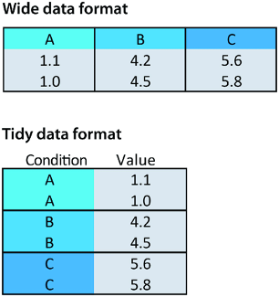

Wide vs long (tidy) data

Mice in 3 groups:

A B en C length of left front paw in cm

Use sensible variable names and include units

## Tidy data

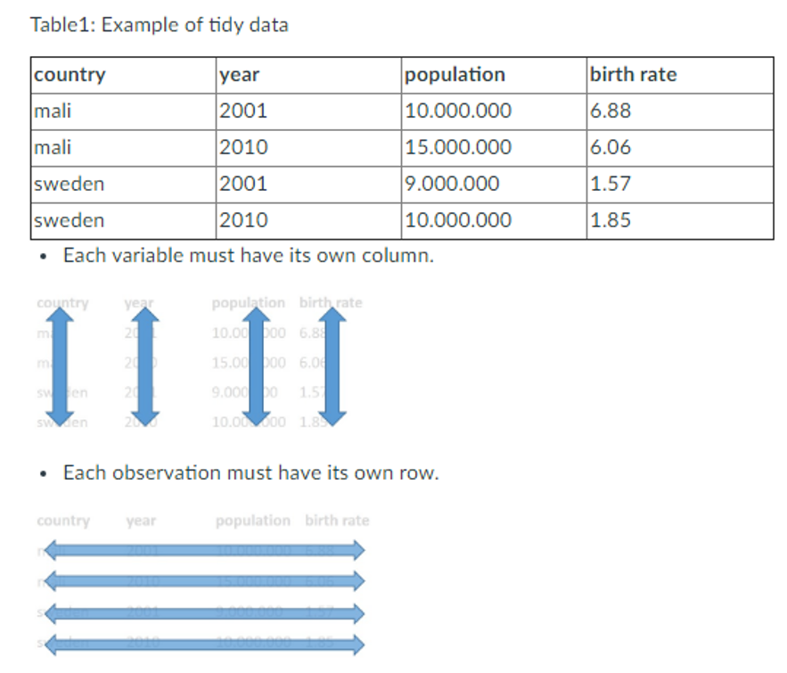

## Tidy data

- Each variable its own column. No duplicate columns. Each observation its own row. Each value must have its own cell.
- One datatype per column, be consistent
- notes in a separate column
- don’t use formatting to convey information
- simple format, fits all (unlike e.g. BITE)

## Reproducible tidy data

- never throw away or change a raw datafile. Raw data = however YOU received the data, be it from a machine, handmade in Excel yourself, or received through email.
- data always needs meta data
- keep data with the interpretation in one project folder.

## Now what about all the rest?

Projects are not just data

## Version control

Which of these issues can you relate to?

- I can’t remake this figure from last year
- I slightly modified my code in one place, everything stopped working
- I have several copies of the same directory because I’m worried about breaking something
- Somebody added erroneous records in a shared file with samples, cannot find who and why
- I have to merge changes to our manuscript from 10 different emails with collaborators
- I came to an old project and forgot where I left/saved it
- My directory is polluted with a lot of unused/temporary/old folders because I’m afraid of losing something important

source: [Source: FAIR in (biological) practice.](https://carpentries-incubator.github.io/fair-bio-practice/11-version-control/index.html) Licensed under [CC-BY 4.0](https://creativecommons.org/licenses/by/4.0/) 2022.

## I am guilty:

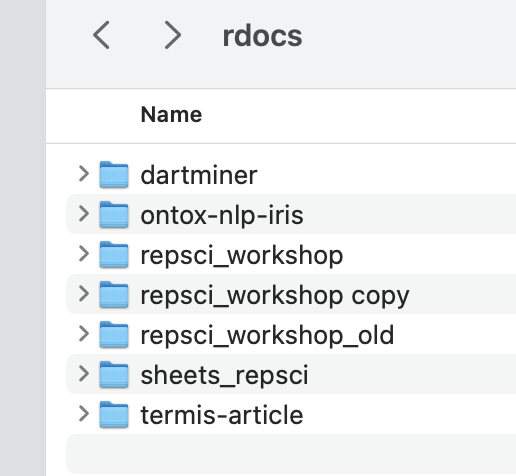

## Changing a file:

- overwrite old content or loose whole files
- may break connections
- may need to merge changes from collaborators

Addressing those issues by tracking changes is called version control.

Information about versions and changes are kept separate from the files.

## Version control

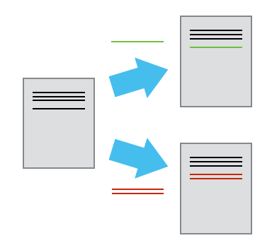

## Version control

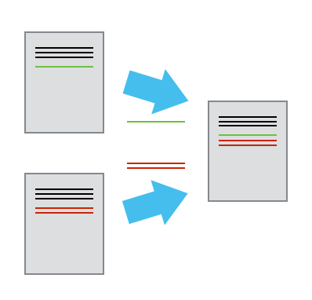

## Exercises regular

- B3: learn to make data tidy
- B4: evaluate your version control
- B5: visualise your data workflow to find your needs for version control

## Exercises next level

- C5: visualise your data workflow to find your needs for version control
- C4: visualise them with `mermaid`

## Location

Breakout rooms, groups of 5

back here at ca 18:10 to discuss your training needs for the coming year.